# Analisando mais a fundo as séries de TV

Paulo Soares

29 de maio de 2017

Olá! Este texto é uma continuação das análises referentes às séries de televisão, cujo contexto é a disciplina de Análise de Dados I, na Universidade Federal de Campina Grande (UFCG).

Vamos explorar os nossos dados e responder perguntas mais capciosas utilizando nossas ferramentas.

# Panorama dos dados

O nossos dados são da plataforma IMDB, e são constituídos por **31 séries**. Vamos considerar, para facilitar a nossa análise, que esses dados são a nossa **população**.

```r
series_from_imdb <- read_csv("../databases/series_from_imdb.csv")
all_series_name <- unique(series_from_imdb$series_name)
#all_series_name
```

Os dados possuem nome, episódio e temporada da série, URL, nome do episódio, avaliação do usuário, quantidade de votos e a proporção de votos de 1-10 para cada episódio.

# Perguntas

Dentro do contexto, foram pensadas duas perguntas sobre as séries:

- 1. Episódios pilotos tem maior nota do que os demais episódios da série?
- 2. A proporção de notas 10 que os episódios de uma série recebe decai ao decorrer das temporadas?

# Uma rápida discussão sobre tamanho da amostra

Uma conclusão mais concreta requer um cálculo especial para aumentar o nível de confiabilidade. Então, vamos ver como calcular o **tamanho da amostra**:

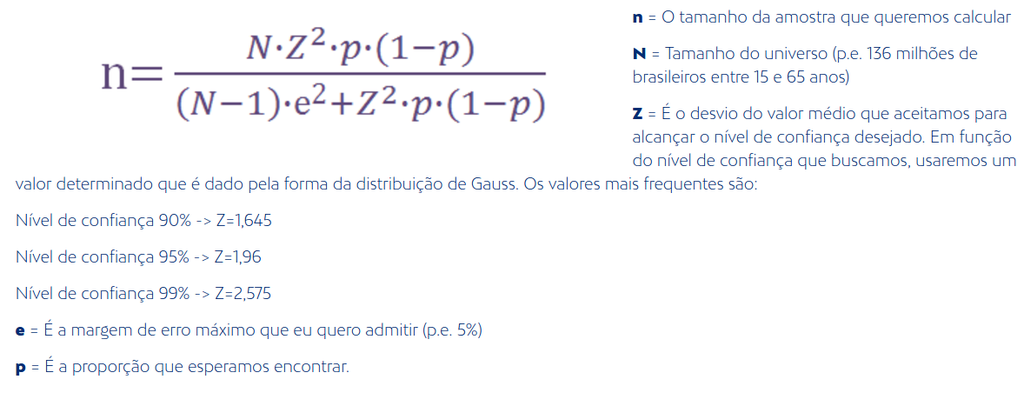

Vamos adotar o valor de p em 0.5 para facilitar, assumindo que a proporção é igual entre séries em que o episódio piloto possui maior valor e onde este não possui o maior valor, para a primeira pergunta, por exemplo. Adotando o valor de Z=2,575 (Nível de confiança 99%) e margem de erro ‘e’ em 0.05, temos o valor da amostra=31, que é semelhante ao valor da população. Isso ocorre porque nossa população é relativamente pequena. Como é inviável plotar as 31 séries, vamos adotar um tamanho de amostra=10, diminuindo um pouco o nível de confiança, mas de forma que podemos obter resultados e discutí-los abaixo.

# Resposta à primeira pergunta:

Nesse contexto, episódios pilotos se referem a todos os primeiros episódios das séries analisadas. A intenção é verificar se este primeiro episódio possui melhor avaliação do que os episódios restantes daquela série. Por melhor avaliação, precisamos definir uma ferramenta de medição, um parâmetro. Temos em nossas mãos a **média** e a **mediana**, novamente. Como vimos na análise passada, a **média** não é o parâmetro de medição mais adequado para esse contexto haja visto que esta é afetada por **valores extremos**, discrepantes de onde há concentração das notas. Como estamos interessados na **constância das notas**, a **mediana** será nosso parâmetro de medição.

A análise se dará da seguinte forma: A nota do episódio piloto será comparada à mediana dos demais episódios da série. Vamos utilizar um gráfico de caixa (boxplot) para mostrar os resultados. Dessa forma também podemos observar a distribuição dos valores, onde estes se concentram, além dos máximos e mínimos. O ponto vermelho representará a nota do episódio piloto. Vamos ver quantos pontos temos acima da mediana, ou seja, quantos pontos ficam acima da barrinha existente no meio do boxplot.  
Vamos escolher uma **amostra aleatória** contendo **10 séries** e, a partir disso, tiramos as nossas conclusões.

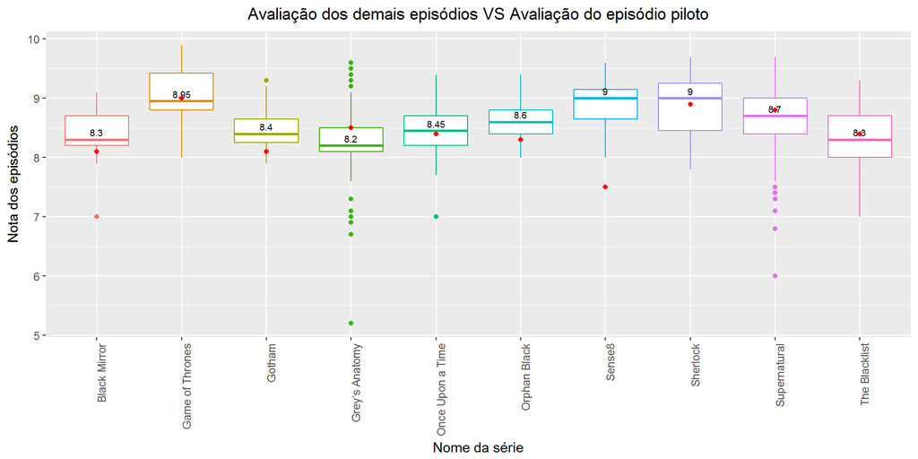

```r
random_choosed_series <- sample(all_series_name, 10)
dataSeries <- series_from_imdb %>% filter(series_name %in% random_choosed_series)

ratings <- dataSeries %>% filter(series_ep %in% 1) %>% filter(season %in% 1)

ggplot(dataSeries, aes(x=series_name, y = UserRating)) + geom_boxplot(aes(color=series_name), show.legend=FALSE) +  stat_summary(aes(label=round(..y..,2)), fun.y=median, geom="text", size=2.5, vjust = -0.5) + ggtitle("Avaliação dos demais episódios VS Avaliação do episódio piloto") + theme(plot.title = element_text(hjust = 0.5)) + xlab("Nome da série") + ylab("Nota dos episódios") + theme(axis.text.x = element_text(angle = 90, hjust = 1)) + geom_point(data=ratings, colour="red")
```

A partir dos resultados vistos acima, podemos concluir que **não é verdade a afirmação à pergunta**, os episódios pilotos nem sempre são melhores do que os demais. Na verdade eles variam muito, podendo ter avaliação iguais ou bem menores do que os demais. Como a amostra é escolhida de forma aleatória, há a possibilidade de pegar séries que tiveram o episódio piloto melhor avaliado, mas no geral isso não é uma verdade absoluta. Também devemos atentar para o nível de confiança da amostra, que é menor que 90%.

## Será que episódios pilotos têm melhor avaliação do que *seasons finales*?

Vamos usar outro gráfico de caixa (boxplot), já que existem mais *seasons finales* do que o episódio piloto. Nossa análise se dará pela **mediana** das notas das *seasons finales* e o ponto vermelho representará a nota do episódio piloto.

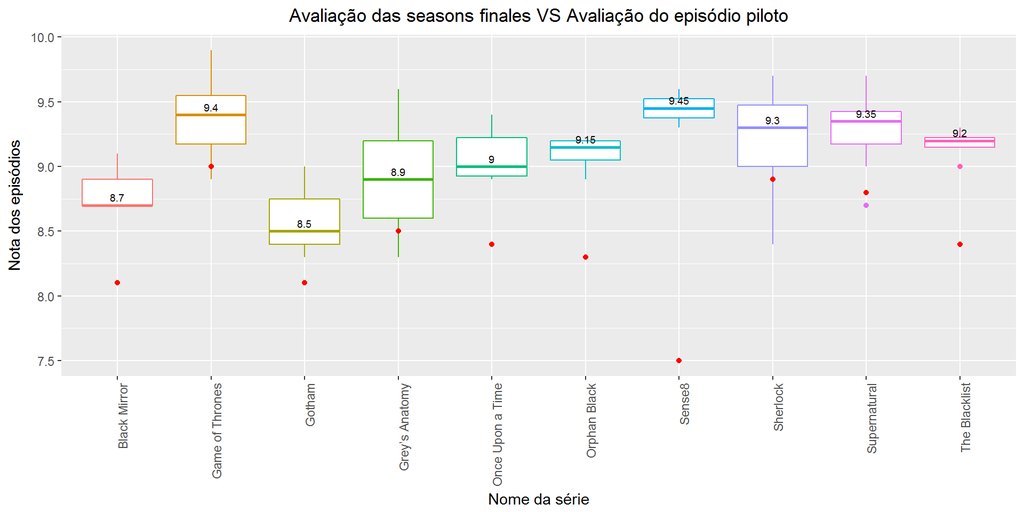

```r
season_finale_eps = dataSeries %>% group_by(series_name, season) %>% summarise(season_ep = max(season_ep))

season_finale_eps$isSeasonFinale <- TRUE

dataSeries <- right_join(season_finale_eps, dataSeries, by=c("series_name","season","season_ep"))

dataSeries$isSeasonFinale <- ifelse(is.na(dataSeries$isSeasonFinale),FALSE,TRUE)

notasSeasonFinale <- dataSeries %>% filter(isSeasonFinale)

ggplot(notasSeasonFinale, aes(x=series_name, y = UserRating)) + geom_boxplot(aes(color=series_name), show.legend=FALSE) +  stat_summary(aes(label=round(..y..,2)), fun.y=median, geom="text", size=2.5, vjust = -0.5) + ggtitle("Avaliação das seasons finales VS Avaliação do episódio piloto") + theme(plot.title = element_text(hjust = 0.5)) + xlab("Nome da série") + ylab("Nota dos episódios") + theme(axis.text.x = element_text(angle = 90, hjust = 1)) + geom_point(data=ratings, colour="red")
```

No gráfico fica bem explícito que **não**. *Seasons finales* possuem avaliação muito melhor que os episódios pilotos para a amostra analisada, levando em consideração a mediana dos episódios.

# Resposta à segunda pergunta:

Vamos escolher uma **amostra aleatória** contendo **10 séries** e, a partir disso, tiramos as nossas conclusões.

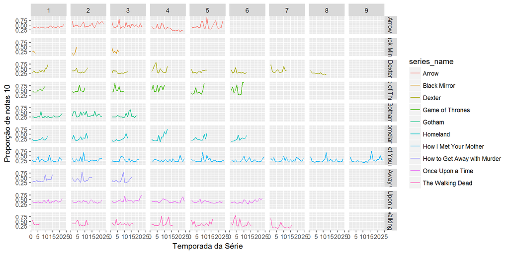

```r
random_choosed_series <- sample(all_series_name, 10)
dataSeries <- series_from_imdb %>% filter(series_name %in% random_choosed_series)

dataSeries %>% ggplot(aes(x = season_ep,y = r10, color = series_name)) + geom_line() + facet_grid(series_name~season)+ labs(x= "Temporada da Série", y= "Proporção de notas 10")
```

## Será que a proporção de notas mínimas para cada episódio aumenta ao decorrer das temporadas?

Para responder essa pergunta, vamos fazer uma análise similar à anterior utilizando as mesmas séries. Vamos utilizar também o mesmo tipo de gráfico, bastando mudar a coluna analisada. Vamos utilizar a coluna ‘r1’ que se refere à proporção de notas 1 que foram dadas à determinado episódio considerando todos os votos para aquele episódio. Vamos verificar o seu comportamento.

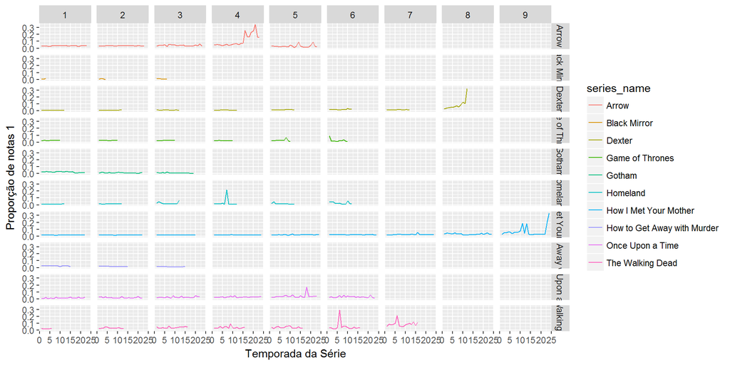

```r
dataSeries %>% ggplot(aes(x = season_ep,y = r1, color = series_name)) + geom_line() + facet_grid(series_name~season)+ labs(x= "Temporada da Série", y= "Proporção de notas 1")
```

A partir do gráfico podemos perceber que não há um padrão claro para aumento das notas dos *haters* ao decorrer das temporadas. Em geral, há uma estabilidade para esse tipo de nota. Picos de nota 1 ocorrem em algumas séries em temporadas aleatórias, mas não há um padrão de crescimento para estas notas.

# Possíveis explicações para os resultados observados

Na primeira pergunta, eu acreditava que os episódios pilotos teriam uma nota mais alta, comparada aos demais, por haver maior esforço em prender a atenção do espectador para que este continuasse assistindo a série, mas isso não ocorre. Na pergunta derivada comprovamos que as *seasons finales* possuem maior nota que os episódios pilotos e isso ocorre por estes episódios trazerem fechamento de tramas e abertura para novos conflitos, o que causa expectativa e imensa ansiedade pelo desfecho por parte do espectador.

Essa foi a análise, espero que tenham gostado! Até a próxima.